# **섹션 1: 그래프 이론**

# **단백질을 위한 그래프 신경망(GNN) 기초**

##[홈페이지로 돌아가기](https://github.com/Graylab/DL4Proteins-notebooks)

**목표: 이 워크숍을 마치면 다음을 수행할 수 있습니다:**

- GNN에 이상적인 데이터 유형과 단백질 구조가 이러한 유형의 신경망에 적합한 이유를 식별합니다.
- 그래프 데이터의 맥락에서 노드와 엣지를 정의합니다. 단백질은 어떻게 그래프로 표현될 수 있습니까?
- 단백질 예측을 위한 노드 수준, 엣지 수준 및 그래프 수준 작업의 예를 듭니다.
- 방향성 엣지와 무방향성 엣지의 차이를 설명합니다.
- GNN의 어떤 작업에 불변성(invariance) 또는 등변성(equivariance)이 필요한지 분류하고 이유를 설명합니다.
- 메시지 전달(message passing)의 단계를 명명하고 설명합니다.
- GNN 내의 다양한 레이어와 다른 모델과의 차이점을 설명합니다.
- 단백질에 대한 노드 수준, 엣지 수준 또는 그래프 수준 질문에 답하기 위해 GNN을 적용합니다.

*작업 내용을 저장하려면 이 노트북의 사본을 개인 Google 드라이브에 저장하세요.*

**목차:**

#### **[섹션 1: 그래프 이론](https://colab.research.google.com/drive/1VdnneRmaBTCfvZgnqZrfVR38xGKYTK2O#scrollTo=2P7qNT_Onfcu)**

- [그래프 이론: 그래프는 어떻게 정의됩니까?](https://colab.research.google.com/drive/1VdnneRmaBTCfvZgnqZrfVR38xGKYTK2O#scrollTo=JHQQO5ETsBLa)
- [그래프 이론: 그래프 예측 작업](https://colab.research.google.com/drive/1VdnneRmaBTCfvZgnqZrfVR38xGKYTK2O#scrollTo=gabWg_OFICy9)
- [그래프 이론: 인접 행렬로의 표현](https://colab.research.google.com/drive/1VdnneRmaBTCfvZgnqZrfVR38xGKYTK2O#scrollTo=hUwUvdnMSHKs&line=1&uniqifier=1)
- [그래프 이론: 방향성 및 무방향성 그래프](https://colab.research.google.com/drive/1VdnneRmaBTCfvZgnqZrfVR38xGKYTK2O#scrollTo=oMwGOPfEFJ9u)
- [그래프 이론: 특징 임베딩으로 노드와 엣지 추가 정의](https://colab.research.google.com/drive/1VdnneRmaBTCfvZgnqZrfVR38xGKYTK2O#scrollTo=rp5_QbFHJksB)

#### **[섹션 2: GNN 이론](https://colab.research.google.com/drive/1VdnneRmaBTCfvZgnqZrfVR38xGKYTK2O#scrollTo=uJIY8IuDnnim)**

- [GNN 이론: 메시지 전달](https://colab.research.google.com/drive/1VdnneRmaBTCfvZgnqZrfVR38xGKYTK2O#scrollTo=6JoRUHFSNrax)
- [GNN 이론: 순열 불변성 vs. 순열 등변성](https://colab.research.google.com/drive/1VdnneRmaBTCfvZgnqZrfVR38xGKYTK2O#scrollTo=GfWjJdfl_OGj)

#### **[섹션 3: GCN 구현](https://colab.research.google.com/drive/1VdnneRmaBTCfvZgnqZrfVR38xGKYTK2O#scrollTo=DmBrwgtVnnuT)**

- [GCN 구현: 입력 데이터 로드 및 준비](https://https://colab.research.google.com/drive/1VdnneRmaBTCfvZgnqZrfVR38xGKYTK2O#scrollTo=Mg5kfaZ0SyBX)
- [GCN 구현: 메시지 전달 함수 정의](https://colab.research.google.com/drive/1VdnneRmaBTCfvZgnqZrfVR38xGKYTK2O#scrollTo=Te_1xM_BMiIy)
- [GCN 구현: GraphConv 레이어 정의](https://colab.research.google.com/drive/1VdnneRmaBTCfvZgnqZrfVR38xGKYTK2O#scrollTo=ozAm0PD2QKhT)
- [GCN 구현: 모델 정의](https://colab.research.google.com/drive/1VdnneRmaBTCfvZgnqZrfVR38xGKYTK2O#scrollTo=1E441Ia5QpT8)
- [GCN 구현: 학습 및 평가](https://colab.research.google.com/drive/1VdnneRmaBTCfvZgnqZrfVR38xGKYTK2O#scrollTo=YSCcSfneQrvJ)

#### **[섹션 4: 목표 확인](https://colab.research.google.com/drive/1VdnneRmaBTCfvZgnqZrfVR38xGKYTK2O#scrollTo=8jkPuq-JC3A4&line=1&uniqifier=1)**

### **라이브러리 임포트**

```python
# Install modules
!pip install graphein
!pip install pytorch3d
!pip install torch-geometric
!pip install torch
!pip install biovec
!pip install biographs
```

```
ERROR: Could not find a version that satisfies the requirement pytorch3d (from versions: none)

ERROR: No matching distribution found for pytorch3d
```

```python
# Get libraries
import os
import re
import graphein
import graphein.protein as gp
from graphein.protein.config import ProteinGraphConfig
from graphein.protein.graphs import construct_graph
from graphein.protein.visualisation import plotly_protein_structure_graph

import pandas as pd
# from Bio import PDB
import numpy as np
from sklearn.model_selection import train_test_split
import matplotlib.pyplot as plt

import networkx as nx
from networkx import to_networkx_graph
import torch
import torch.nn as nn
from torch_geometric.utils import from_networkx
from torch_geometric.data import Data
from torch_geometric.loader import DataLoader
import torch.nn.functional as F
from torch_geometric.nn import GCNConv, global_mean_pool, global_max_pool
import biographs as bg
import Bio.PDB
from biopandas.pdb import PandasPdb
# from plotly.subplots import make_subplots
```

```python
# Clone the repository with sparse checkout and depth limit
!git clone -n --depth=1 --filter=tree:0 \
  https://github.com/courtel/GNN_dl_workshop.git repo_partial


%cd repo_partial # Get into cloned repo
!git sparse-checkout set --no-cone images # Sparse checkout to fetch only specified folder
!git checkout

%cd ..
!mv repo_partial/images ./images
!rm -rf repo_partial
```

[output not shown]

그래프는 우리 주변 세계에 매우 만연해 있습니다. 그래프는 객체 간의 복잡한 관계를 포착할 수 있기 때문에 데이터를 표현하는 강력한 방법입니다. 소셜 네트워크, 교통 네트워크, 통신 네트워크, 지식 그래프(검색 엔진 등), 심지어 문장 속의 단어까지도 그래프로 표현할 수 있습니다. 그래프는 로컬(노드 수준) 및 글로벌(그래프 수준) 정보를 모두 표현할 수 있어 모델링 대상의 전체 복잡성을 포착합니다.

대부분의 신경망은 유클리드 데이터에서 작동합니다. 예를 들어, 이미지는 노드와 엣지의 격자 모양의 정렬된 구조에 따라 기능이 달라지는 CNN에서 이상적으로 처리되는 선형 그래프입니다. GNN은 소셜 네트워크와 같이 더 복잡하고 예측하기 어려운 비선형 데이터에 사용할 수 있습니다.

```python
# @title Hover over the nodes, edges, and graph border to see embeddings for each.


from IPython.display import HTML, display

# Load D3.js
display(HTML("""
<script src="https://d3js.org/d3.v6.min.js"></script>
"""))

html_code = """
<div id="container">
  <div>
    </div>
    <div style="display: flex; align-items: flex-start;">
      <div>
        <h2>Grid-like Image Graph</h2>
        <div id="grid-image"></div>
      </div>
      <div style="margin-left: 20px;">
        <h2>Social Network Graph</h2>
        <div id="social-network-graph"></div>
      </div>
    </div>
  </div>
</div>

<style>
  h2 {
    text-align: center;
  }

  .node {
    stroke: #bbb;
    stroke-width: 1px;
  }

  .node.hovered {
    stroke-width: 3px;
    stroke: #1f77b4;
  }

  .edge {
    stroke: #bbb;
    stroke-width: 1px;
  }

  .edge.hovered {
    stroke-width: 3px;
    stroke: #ff7f0e;
  }

  .overlay {
    fill: rgba(0, 0, 0, 0);
    cursor: pointer;
  }

  .graph {
    stroke: #bbb;
    stroke-width: 4px;
    fill: none;
  }

  .graph.hovered {
    stroke: #2ca02c;
    stroke-width: 10px;
  }

  .tooltip {
    position: absolute;
    background-color: #fff;
    border: 1px solid #bbb;
    padding: 5px;
    border-radius: 3px;
    pointer-events: none;
    font-size: 12px;
  }
</style>

<div class="tooltip" id="tooltip" style="display: none;"></div>

<script>
  function makeGridImage() {
    const gridSize = 5;  // Change this to adjust the grid size (e.g., 5x5 grid)
    const nodes = [];
    const links = [];

    for (let i = 0; i < gridSize; i++) {
      for (let j = 0; j < gridSize; j++) {
        const id = i * gridSize + j;
        nodes.push({
          id: id,
          x: j / (gridSize - 1),
          y: i / (gridSize - 1),
          element: `P(${i},${j})`,
          features: `Pixel (${i},${j})`
        });

        // Connect the node to its right neighbor
        if (j < gridSize - 1) {
          links.push({ source: id, target: id + 1 });
        }

        // Connect the node to its bottom neighbor
        if (i < gridSize - 1) {
          links.push({ source: id, target: id + gridSize });
        }
      }
    }

    const graph = { features: 'Grid Image Representation: ...' };

    return [nodes, links, graph];
  }

  function makeSocialNetworkGraph() {
    const numNodes = 50;
    const nodes = Array.from({ length: numNodes }, (v, i) => ({
      id: i,
      x: Math.random(),
      y: Math.random(),
      name: `User ${i}`,
      features: `Embeddings: ${Math.random().toFixed(4)}, ${Math.random().toFixed(4)}`
    }));

    const links = [];
    for (let i = 0; i < numNodes; i++) {
      for (let j = i + 1; j < numNodes; j++) {
        if (Math.random() < 0.1) {
          links.push({
            source: i,
            target: j,
            connection: 'friend',
            features: `Connection strength: ${Math.random().toFixed(4)}`
          });
        }
      }
    }

    const graph = { features: 'Social Network Graph Embeddings: ...' };

    return [nodes, links, graph];
  }

  class GraphDescription {
    constructor(elementId, makeGraphFunction) {
      this.parent = d3.select(`#${elementId}`);
      this.svg = this.parent.append('svg')
                            .attr('width', 400)
                            .attr('height', 400);
      const [nodes, links, graph] = makeGraphFunction();
      this.showGraph(nodes, links, graph);
    }

    showGraph(nodes, links, graph) {
      const pos = (x) => x * 350 + 25;
      const tooltip = d3.select('#tooltip');
      const self = this;
      const graphHolder = this.svg.append('g')
                                  .attr('transform', 'translate(10, 10)');

      const graphBorder = graphHolder.append('rect')
        .attr('width', 350)
        .attr('height', 350)
        .attr('x', 0)
        .attr('y', 0)
        .attr('rx', 20)
        .attr('class', 'graph')
        .on('mouseover', function(event) { self.showGraphTooltip(event, graph, tooltip); })
        .on('mouseout', function() { self.hideTooltip(tooltip); });

      const edgeElements = graphHolder.selectAll('line.edge')
        .data(links)
        .enter()
        .append('line')
        .classed('edge', true)
        .attr("x1", (d) => pos(nodes[d.source].x))
        .attr("x2", (d) => pos(nodes[d.target].x))
        .attr("y1", (d) => pos(nodes[d.source].y))
        .attr("y2", (d) => pos(nodes[d.target].y))
        .on('mouseover', function(event, d) { self.showEdgeTooltip(event, d, nodes, tooltip); })
        .on('mouseout', function() { self.hideTooltip(tooltip); });

      graphHolder.selectAll('line.overlay')
        .data(links)
        .enter()
        .append('line')
        .classed('overlay', true)
        .attr("x1", (d) => pos(nodes[d.source].x))
        .attr("x2", (d) => pos(nodes[d.target].x))
        .attr("y1", (d) => pos(nodes[d.source].y))
        .attr("y2", (d) => pos(nodes[d.target].y))
        .on('mouseover', function(event, d) { self.showEdgeTooltip(event, d, nodes, tooltip); })
        .on('mouseout', function() { self.hideTooltip(tooltip); });

      const nodeElements = graphHolder.selectAll('circle.node')
        .data(nodes)
        .enter()
        .append('circle')
        .classed('node', true)
        .attr('r', 7)
        .attr('cx', (d) => pos(d.x))
        .attr('cy', (d) => pos(d.y))
        .on('mouseover', function(event, d) { self.showNodeTooltip(event, d, tooltip); })
        .on('mouseout', function() { self.hideTooltip(tooltip); });

      graphHolder.selectAll('circle.overlay')
        .data(nodes)
        .enter()
        .append('circle')
        .classed('overlay', true)
        .attr('r', 12)
        .attr('cx', (d) => pos(d.x))
        .attr('cy', (d) => pos(d.y))
        .on('mouseover', function(event, d) {
          d3.select(nodeElements.nodes()[d.id]).classed('hovered', true);
          d3.select(this).classed('hovered', true);
          self.showNodeTooltip(event, d, tooltip);
        })
        .on('mouseout', function(event, d) {
          d3.select(nodeElements.nodes()[d.id]).classed('hovered', false);
          d3.select(this).classed('hovered', false);
          self.hideTooltip(tooltip);
        });

      graphBorder.on('mouseover', function(event) {
        d3.select(this).classed('hovered', true);
        edgeElements.classed('hovered', true);
        nodeElements.classed('hovered', true);
        self.showGraphTooltip(event, graph, tooltip);
      })
      .on('mouseout', function() {
        d3.select(this).classed('hovered', false);
        edgeElements.classed('hovered', false);
        nodeElements.classed('hovered', false);
        self.hideTooltip(tooltip);
      });
    }

    showNodeTooltip(event, d, tooltip) {
      tooltip.style('display', 'block')
             .style('left', (event.pageX + 5) + 'px')
             .style('top', (event.pageY + 5) + 'px')
             .html(`<strong>ID:</strong> ${d.id}<br><strong>Features:</strong> ${d.features}`);
      d3.select(event.target).classed('hovered', true);
    }

    showEdgeTooltip(event, d, nodes, tooltip) {
      const sourceNode = nodes[d.source];
      const targetNode = nodes[d.target];
      tooltip.style('display', 'block')
            .style('left', (event.pageX + 5) + 'px')
            .style('top', (event.pageY + 5) + 'px')
            .html(`<strong>Source:</strong> ${sourceNode.id} (${sourceNode.features})<br><strong>Target:</strong> ${targetNode.id} (${targetNode.features})`);
      d3.select(event.target).classed('hovered', true);
    }

    showGraphTooltip(event, graph, tooltip) {
      tooltip.style('display', 'block')
            .style('left', (event.pageX + 5) + 'px')
            .style('top', (event.pageY + 5) + 'px')
            .html(`<strong>Graph:</strong> ${graph.features}`);
      d3.select(event.target).classed('hovered', true);
    }

    hideTooltip(tooltip) {
      tooltip.style('display', 'none');
      d3.selectAll('.hovered').classed('hovered', false);
    }
  }

  const gridImageGraph = new GraphDescription('grid-image', makeGridImage);
  const socialNetworkGraph = new GraphDescription('social-network-graph', makeSocialNetworkGraph);
</script>
"""

display(HTML(html_code))
```

Grid-like Image Graph

Social Network Graph

분자는 원자를 노드로, 결합을 엣지로 하여 쉽게 그래프로 표현할 수 있습니다. 아래는 시트로넬라 오일에 독특한 레몬 향을 부여하는 데 사용되는 시트로넬랄 분자의 예입니다.

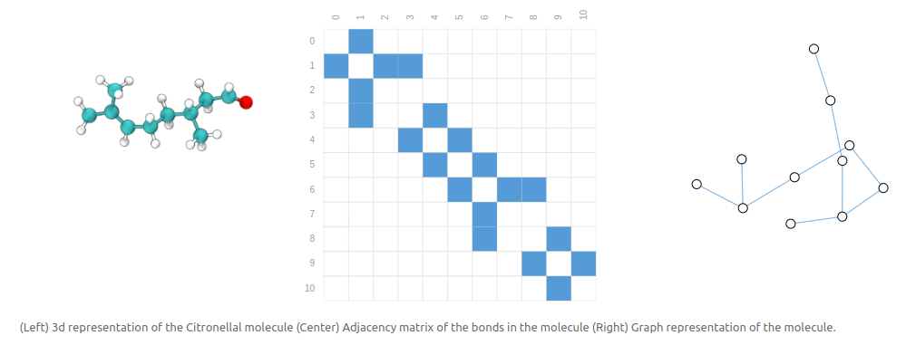

*이미지 출처: [그래프 신경망에 대한 완만한 소개](https://distill.pub/2021/gnn-intro/)*

## **그래프 이론: 그래프는 어떻게 정의됩니까?**

```python
# @title A graph **G** is a data structure that can be defined as **G = (V, E)**, where **V** represents the vertices (or nodes) and **E** represents the edges. Edges in a graph can be directed or undirected based on whether directional dependencies exist between nodes.
from IPython.display import HTML, display

# Load D3.js
display(HTML("""
<script src="https://d3js.org/d3.v6.min.js"></script>
"""))

html_code = """
<div id="container" style="display: flex; align-items: flex-start;">
  <div id="graph-description"></div>
  <div id="text-description"></div>
</div>

<style>
  .line-holder {
    display: flex;
    flex-direction: column;
    margin: 10px 0;
    width: 100%;
  }
  .line-holder div {
    margin: 5px 0;
  }
  .letter {
    font-weight: bold;
    margin-right: 10px;
    font-size: 2em;
  }
  .desc {
    font-size: 2em;
    margin-right: 10px;
    margin-left: 5px;
    white-space: pre-wrap;
  }
  .line-holder .top-line {
    display: flex;
    align-items: center;
  }
  .eg {
    font-size: 1.5em;
    margin-left: 20px;
  }
  .selected {
    background-color: #ddd;
  }
  svg {
    margin: 20px;
    border: 1px solid black;
  }
</style>

<script>
function makeGraph() {
  const nodes = [
    { id: 0, x: 0.8, y: 0.5 },
    { id: 1, x: 0.6, y: 0.9 },
    { id: 2, x: 0.2, y: 0.8 },
    { id: 3, x: 0.2, y: 0.4 },
    { id: 4, x: 0.6, y: 0.1 }
  ];
  const links = [
    { a: nodes[0], b: nodes[0] },
    { a: nodes[0], b: nodes[4] },
    { a: nodes[4], b: nodes[0] },
    { a: nodes[4], b: nodes[1] },
    { a: nodes[1], b: nodes[2] },
    { a: nodes[2], b: nodes[1] },
    { a: nodes[2], b: nodes[2] },
    { a: nodes[2], b: nodes[4] },
    { a: nodes[4], b: nodes[2] },
    { a: nodes[3], b: nodes[3] },
    { a: nodes[3], b: nodes[0] },
    { a: nodes[0], b: nodes[3] },
    { a: nodes[4], b: nodes[4] },
    { a: nodes[4], b: nodes[1] },
    { a: nodes[1], b: nodes[4] },
    { a: nodes[4], b: nodes[3] },
    { a: nodes[3], b: nodes[4] }
  ];
  return [nodes, links];
}

class GraphDescription {
  constructor() {
    this.parent = d3.select('#graph-description');
    this.svg = this.parent.append('svg')
                          .attr('width', 400)
                          .attr('height', 400);
    const [nodes, links] = makeGraph();
    this.showGraph(nodes, links);
    this.showText();
  }

  showGraph(nodes, links) {
    const pos = (x) => x * 300 + 50;

    const graphHolder = this.svg.append('g')
                                .attr('transform', 'translate(25, 25)');

    // Make global box
    graphHolder.append('rect')
      .attr('width', 350)
      .attr('height', 350)
      .attr('x', 0)
      .attr('y', 0)
      .attr('rx', 20)
      .attr('fill', '#fff')
      .attr('stroke', '#ddd')
      .style("stroke-width", 2)
      .attr('stroke-dasharray', "4, 4")
      .on('mouseover', () => this.highlightGlobal())
      .on('mouseout', () => this.unhighlightAll());

    // Make edges
    graphHolder.selectAll('line.vis')
      .data(links)
      .enter()
      .append('line')
      .classed('vis', true)
      .style("stroke", "#bbb")
      .style("stroke-width", 1)
      .attr("x1", (d) => pos(d.a.x))
      .attr("x2", (d) => pos(d.b.x))
      .attr("y1", (d) => pos(d.a.y))
      .attr("y2", (d) => pos(d.b.y));

    graphHolder.selectAll('line.target')
      .data(links)
      .enter()
      .append('line')
      .classed('target', true)
      .style("stroke", "rgba(0, 0, 0, 0)")
      .style("stroke-width", 40)
      .attr("x1", (d) => pos(d.a.x))
      .attr("x2", (d) => pos(d.b.x))
      .attr("y1", (d) => pos(d.a.y))
      .attr("y2", (d) => pos(d.b.y))
      .on('mouseover', () => this.highlightEdges())
      .on('mouseout', () => this.unhighlightAll());

    // Make nodes
    graphHolder.selectAll('circle')
      .data(nodes)
      .enter()
      .append('circle')
      .attr('r', 10)
      .attr('cx', (d) => pos(d.x))
      .attr('cy', (d) => pos(d.y))
      .style('fill', '#fff')
      .style("stroke-width", '1px')
      .style("stroke", '#bbb')
      .on('mouseover', () => this.highlightNodes())
      .on('mouseout', () => this.unhighlightAll());
  }

  showText() {
    const textHolder = d3.select('#text-description');

    const makeLine = (letter, desc, eg, mouseover) => {
      const div = textHolder.append('div')
        .classed('line-holder', true)
        .attr('id', letter);
      const topLine = div.append('div').classed('top-line', true);
      topLine.append('div').text(letter).classed('letter', true);
      topLine.append('div').text(desc).classed('desc', true);
      div.append('div').text(eg).classed('eg', true);

      div.on('mouseover', mouseover);
      div.on('mouseout', () => this.unhighlightAll());
    }

    makeLine('V', ' Vertex (or node) attributes', 'e.g., node identity, number of neighbors', () => this.highlightNodes());
    makeLine('E', ' Edge attributes and directions', 'e.g., edge identity, edge weight', () => this.highlightEdges());
    makeLine('G', ' Graph attributes', 'e.g., number of nodes, longest path', () => this.highlightGlobal());
  }

  highlightEdges() {
    d3.select('#E').classed('selected', true);
    this.parent.selectAll('line.vis')
      .style("stroke", "#000")
      .style("stroke-width", 10);
  }

  highlightNodes() {
    d3.select('#V').classed('selected', true);
    this.parent.selectAll('circle')
      .style("stroke-width", 6)
      .style("stroke", '#000')
      .attr("r", 11);
  }

  highlightGlobal() {
    d3.select('#G').classed('selected', true);
    this.parent.selectAll('rect')
      .style("stroke", '#000')
      .style("stroke-width", 40);
  }

  unhighlightAll() {
    d3.selectAll('.line-holder').classed('selected', false);
    this.parent.selectAll('line.vis')
      .style("stroke", "#bbb")
      .style("stroke-width", '1px');

    this.parent.selectAll('circle')
      .style("stroke-width", '1px')
      .style("stroke", '#aaa')
      .attr("r", 10);

    this.parent.selectAll('rect')
      .style("stroke-width", 2)
      .style("stroke", '#ddd');
  }
}

const graph = new GraphDescription();
</script>
"""

display(HTML(html_code))

# adapted from https://distill.pub/2021/gnn-intro/
```

*Adapted from: [A Gentle Introduction to Graph Neural Networks](https://distill.pub/2021/gnn-intro/)*

## **그래프 이론: 그래프 예측 작업**

그래프에서 어떤 종류의 문제를 해결할 수 있습니까?

1. **노드 수준 작업**은 그래프의 노드를 분류하는 것을 포함합니다.
2. **엣지 수준 작업**(또는 링크 예측)은 그래프의 노드 쌍 간의 관계를 포함합니다.
3. **그래프 수준 작업**은 전체 그래프를 아우르는 속성을 포함합니다.

```python
# @markdown **<font color='#e59454'>Question Time! Run to Show Question**

from IPython.display import display, HTML
import json  # Required for converting Python dictionaries to JSON strings

# Words and definitions to match
words = ["Node-level task", "Edge-level task", "Graph-level task"]
definitions = [
    "Predict different types of residue interactions (e.g., hydrogen bond, ionic bond, hydrophobic interaction).",
    "Predict the overall stability of the protein.",
    "Predict the B-factor for each residue.",
]

correct_definitions = {
    "Node-level task": "Predict the B-factor for each residue.",
    "Edge-level task": "Predict different types of residue interactions (e.g., hydrogen bond, ionic bond, hydrophobic interaction).",
    "Graph-level task": "Predict the overall stability of the protein.",
}

explanation = """
<p></p>
<ol>
    <li><strong>Node-level task:</strong> Predict the B-factor for each residue.</li>
    <li><strong>Edge-level task:</strong> Predict different types of residue interactions (e.g., hydrogen bond, ionic bond, hydrophobic interaction).</li>
    <li><strong>Graph-level task:</strong> Predict the overall stability of the protein.</li>
</ol>
"""

# Create the matching quiz with dropdowns
def create_matching_quiz(words, definitions, explanation):
    html_code = "<h3>Match the problem to solve with the correct task level:</h3>"

    for i, word in enumerate(words):
        html_code += f"<p><strong>{word}:</strong> " \
                     f"<select id='dropdown_{i}'>" \
                     f"<option value='' disabled selected>Select task</option>"
        for definition in definitions:
            html_code += f"<option value='{definition}'>{definition}</option>"
        html_code += "</select></p>"

    # Add submit button, feedback, and explanation
    html_code += f"""
      <button onclick="checkAnswers()">Submit</button>
      <button onclick="showExplanation()">Show Explanation</button>
      <p id="feedback" style="font-weight: bold;"></p>
      <div id="explanation" style="display:none; margin-top: 20px; padding: 10px; border: 1px solid #ccc; background-color: #f9f9f9;">
        <h4>Explanation:</h4>
        {explanation}
      </div>
    <script>
    // JavaScript function to check answers
    function checkAnswers() {{
        // Pass the Python data into JavaScript variables
        var correct_answers = {json.dumps(correct_definitions)};
        var feedback = document.getElementById('feedback');
        var correct = true;

        // Loop through each dropdown and check if the selected answer is correct
        Object.keys(correct_answers).forEach(function(word, index) {{
            var dropdown = document.getElementById('dropdown_' + index);
            var selected_answer = dropdown.value;

            if (selected_answer === correct_answers[word]) {{
                dropdown.style.color = "green";
            }} else {{
                dropdown.style.color = "red";
                correct = false;
            }}
        }});

        // Update feedback based on correctness
        if (correct) {{
            feedback.textContent = "Correct!";
            feedback.style.color = "green";
        }} else {{
            feedback.textContent = "Incorrect. Try again.";
            feedback.style.color = "red";
        }}
    }}

    // JavaScript function to show explanation
    function showExplanation() {{
        var explanationDiv = document.getElementById('explanation');
        explanationDiv.style.display = "block";
    }}
    </script>
    """

    display(HTML(html_code))

# Call the function to create the matching quiz
create_matching_quiz(words, definitions, explanation)
```

Match the problem to solve with the correct task level:

**Node-level task:**

**Edge-level task:**

**Graph-level task:**